# Multi-State Model

# Multi-state model with msm package

- Ref: [Multi-state modelling with R: the msm package](https://cran.r-project.org/web/packages/msm/vignettes/msm-manual.pdf)
- Informative sampling times
  - Fixed: patients are observed at fixed time intervals specified in advance
  - Random: the sampling times are independent of the current state of the disease
  - Doctor’s care: the next sampling time is chosen on the basis of the current disease state (more severe ill patients are monitored more closely)
  - Patient self-selection: patients decide to see doctors when they are in poor conditions
- $$P(t) = Exp(tQ)$$
  - $P$ is the probability of transition during the time $t$
  - $Q$ is the transition intensity maxtrix
  - $Exp$ is the matrix exponential
- Interval censored: in the intermittently-observed processess, the exact times of the state changes are usually interval censored, it is known to be within the bounded intervals.
- Sojourn Time: a single period of occupancy

## CAV Data

Sharples et al. studied the progression of coronary allograft vasculopathy (CAV), a post-transplant deterioration of the arterial walls, using these data. Risk factors and the accuracy of the screening test were investigated using multi-state Markov and hidden Markov models.

- 622 patients
- Approximately each year after transplant, every patient has an angiograme when CAV could be diagnosed.
- age: age at screen
- dage: donor’s age
- sex: 0=male, 1=female
- pdiag: primary diagnosis
- cumrej: cumulative number of rejection episodes
- firstobs: 1 = the first observation (transplant), 0 = later angiogram

L.D. Sharples, C.H. Jackson, J. Parameshwar, J. Wallwork, and S.R. Large. Diagnostic accuracy of coronary angiography and risk factors for post-heart-transplant cardiac allograft vasculopathy. Transplantation, 76(4):679682, 2003.

```r
library(msm)
cav %>% DT()
```

| PTNUM | age | years | dage | sex | pdiag | cumrej | state | firstobs | statemax |
| --- | --- | --- | --- | --- | --- | --- | --- | --- | --- |
| 100002 | 52.4958904109589 | 0 | 21 | 0 | IHD | 0 | 1 | 1 | 1 |
| 100002 | 53.4986301369863 | 1.0027397260274 | 21 | 0 | IHD | 2 | 1 | 0 | 1 |
| 100002 | 54.4986301369863 | 2.0027397260274 | 21 | 0 | IHD | 2 | 2 | 0 | 2 |
| 100002 | 55.5890410958904 | 3.09315068493151 | 21 | 0 | IHD | 2 | 2 | 0 | 2 |
| 100002 | 56.4958904109589 | 4 | 21 | 0 | IHD | 3 | 2 | 0 | 2 |
| 100002 | 57.4931506849315 | 4.9972602739726 | 21 | 0 | IHD | 3 | 3 | 0 | 3 |
| 100002 | 58.3506849315068 | 5.85479452054795 | 21 | 0 | IHD | 3 | 4 | 0 | 4 |
| 100003 | 29.5068493150685 | 0 | 17 | 0 | IHD | 0 | 1 | 1 | 1 |
| 100003 | 30.6958904109589 | 1.18904109589041 | 17 | 0 | IHD | 1 | 1 | 0 | 1 |
| 100003 | 31.5150684931507 | 2.00821917808219 | 17 | 0 | IHD | 1 | 3 | 0 | 3 |

[output cut: 2836 more lines]

## Data Summary

```r
Vars <- c(
    "age"
  , "years"
  , "dage"
  , "sex"
  , "pdiag"
  , "cumrej"
  , "state"
)

FactorVars <- c(
    "sex"
  , "pdiag"
  , "cumrej"
  , "state"
)

t <- Table1n(obj = cav, Vars = Vars, FactorVars = FactorVars)

t %>% prt()
```

| what | level | Overall | Overall | Missing |
| --- | --- | --- | --- | --- |
| n |  | 2846 | 2846 |  |
| age | mean (SD) | 48.9 (10.9) | 48.9 (10.9) | 0.0 |
|  | median [IQR] | 51.2 [43.7, 56.7] | 51.2 [43.7, 56.7] | 0.0 |
|  | median [range] | 51.2 [6.3, 74.3] | 51.2 [6.3, 74.3] | 0.0 |
| years | mean (SD) | 3.8 (3.3) | 3.8 (3.3) | 0.0 |
|  | median [IQR] | 3.9 [1.0, 6.0] | 3.9 [1.0, 6.0] | 0.0 |
|  | median [range] | 3.9 [0.0, 19.5] | 3.9 [0.0, 19.5] | 0.0 |
| dage | mean (SD) | 28.8 (11.4) | 28.8 (11.4) | 0.0 |
|  | median [IQR] | 26.0 [19.0, 37.0] | 26.0 [19.0, 37.0] | 0.0 |
|  | median [range] | 26.0 [0.0, 61.0] | 26.0 [0.0, 61.0] | 0.0 |
| sex (%) | 0 | 2504 (88.0) | 2504 (88.0) | 0.0 |
|  | 1 | 342 (12.0) | 342 (12.0) |  |
| pdiag (%) | CVCM | 88 ( 3.1) | 88 ( 3.1) | 1.1 |
|  | Hyper | 7 ( 0.2) | 7 ( 0.2) |  |
|  | IDC | 1283 (45.1) | 1283 (45.1) |  |
|  | IHD | 1413 (49.6) | 1413 (49.6) |  |
|  | Other | 10 ( 0.4) | 10 ( 0.4) |  |
|  | Restr | 15 ( 0.5) | 15 ( 0.5) |  |
|  | NA | 30 ( 1.1) | 30 ( 1.1) |  |
| cumrej (%) | 0 | 1082 (38.0) | 1082 (38.0) | 0.0 |
|  | 1 | 557 (19.6) | 557 (19.6) |  |
|  | 2 | 425 (14.9) | 425 (14.9) |  |
|  | 3 | 294 (10.3) | 294 (10.3) |  |
|  | 4 | 179 ( 6.3) | 179 ( 6.3) |  |
|  | 5 | 159 ( 5.6) | 159 ( 5.6) |  |
|  | 6 | 73 ( 2.6) | 73 ( 2.6) |  |
|  | 7 | 42 ( 1.5) | 42 ( 1.5) |  |
|  | 8 | 26 ( 0.9) | 26 ( 0.9) |  |
|  | 9 | 3 ( 0.1) | 3 ( 0.1) |  |
|  | 10 | 1 ( 0.0) | 1 ( 0.0) |  |
|  | 11 | 2 ( 0.1) | 2 ( 0.1) |  |
|  | 12 | 3 ( 0.1) | 3 ( 0.1) |  |
| state (%) | 1 | 2039 (71.6) | 2039 (71.6) | 0.0 |
|  | 2 | 351 (12.3) | 351 (12.3) |  |
|  | 3 | 205 ( 7.2) | 205 ( 7.2) |  |
|  | 4 | 251 ( 8.8) | 251 ( 8.8) |  |

## Description

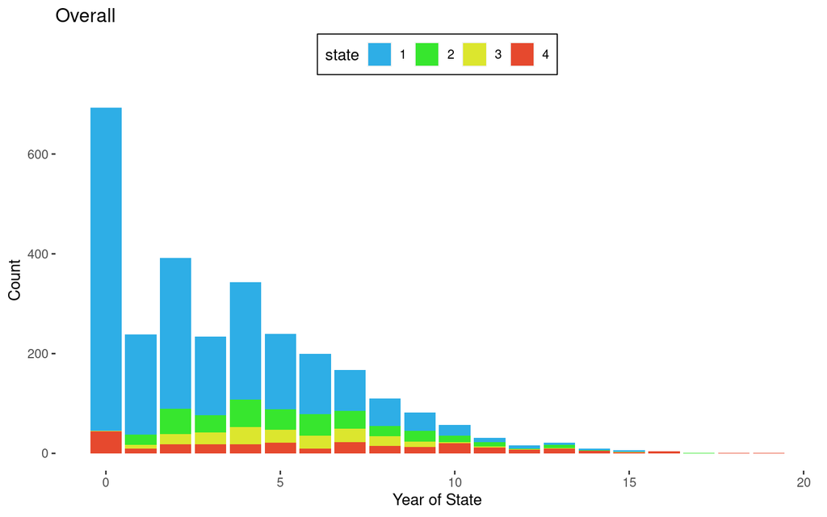

```r
dt <- cav
setDT(dt)
dt <- dt[, state := factor(state)][, years := as.integer(floor(years))]

clrs <- c("#2EAEE6"
        ## , "#2EE6CA"
        ## , "#2EE677"
        , "#37E62E"
        ## , "#8AE62E"
        , "#DCE62E"
        ## , "#E69C2E"
        , "#E6492E"
          ## , "#aaaaaa"
          )


ggplot(dt, aes(x=years, fill = state)) + geom_bar() +
    scale_fill_manual(values = clrs) +
    labs(x="Year of State"
       , y="Count"
       , title="Overall"
         ) +
    ## scale_x_discrete(breaks=seq(0, 20, 5)) +
    ## scale_y_continuous(breaks=seq(1, 5, 1)) +
    theme(panel.background = element_rect(fill = "transparent")
        , plot.background = element_rect(fill = "transparent", color = NA)
        , panel.grid.major = element_blank()
        , panel.grid.minor = element_blank()
        , legend.background = element_rect(fill = "transparent")
        , legend.box.background = element_rect(fill = "transparent")
        , legend.position = 'top'
        ## , plot.margin=unit(c(1,2,1,2),"cm")
          ) +
    ## coord_fixed(ratio = 3 / 2
              ## , xlim = c(0.5, 28.5)
              ## , ylim = c(0.5, 10.5)
              ## , expand = FALSE) +
    guides(fill = guide_legend(nrow = 1))
```

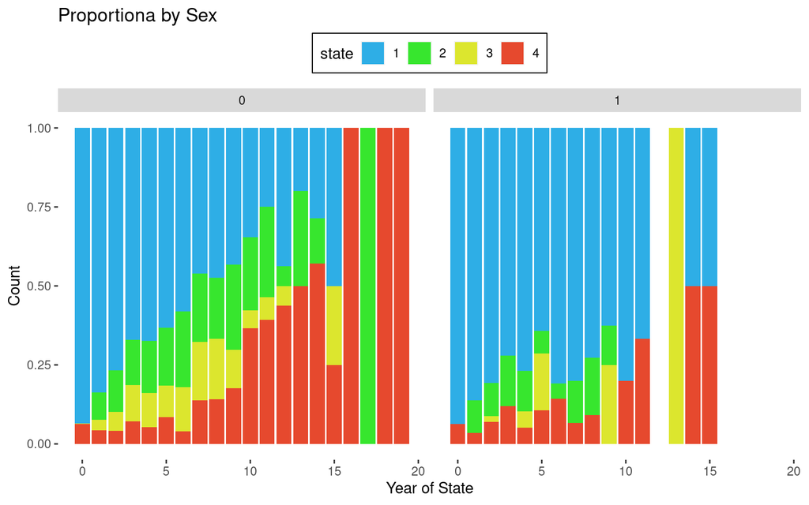

```r
ggplot(dt, aes(x=years, fill = state)) + geom_bar(position = "fill") +
    scale_fill_manual(values = clrs) +
    labs(x="Year of State"
       , y="Count"
       , title="Proportiona by Sex"
         ) +
    ## scale_x_discrete(breaks=seq(0, 20, 5)) +
    ## scale_y_continuous(breaks=seq(1, 5, 1)) +
    facet_wrap(as.formula(paste0("~", "sex"))) +
    theme(panel.background = element_rect(fill = "transparent")
        , plot.background = element_rect(fill = "transparent", color = NA)
        , panel.grid.major = element_blank()
        , panel.grid.minor = element_blank()
        , legend.background = element_rect(fill = "transparent")
        , legend.box.background = element_rect(fill = "transparent")
        , legend.position = 'top'
        ## , plot.margin=unit(c(1,2,1,2),"cm")
          ) +
    ## coord_fixed(ratio = 3 / 2
              ## , xlim = c(0.5, 28.5)
              ## , ylim = c(0.5, 10.5)
              ## , expand = FALSE) +
    guides(fill = guide_legend(nrow = 1))
```

## Simple bidirectional model

- Death is the absorbing state
- The day of death is assumed to be recorded exactly. The state 4 is death, deathexact=4
- If the data has two death states 4 and 5 with two competing risks, deathexact=c(4,5)
- State transition table: from state (in row) to state (in column)
- Transition intensity matrix Q: zeros in the matrix
- obstype: a vector specifying the observation scheme for each row of the data
  - =1: a snapthot of the process, the states are unkown between observation times
  - =2: an exact transition time, the state at the previous observation retained untile the current observation
  - =3: an exact transition time, but the state at the instant before entering this state is unknown.
  - exacttime=TRUE: all observations are of obstype 2.
  - deathexact=death.states specifies that all observations of death.states are of type 3.
  - deathexact=TRUE specifies all observations in the final absorbing state are of type 3.

```r
library(msm)


t <- statetable.msm(state, PTNUM, data=cav)

t %>% as.data.frame.matrix() %>% prt(caption="Transition Frequencies")
```

Transition Frequencies

| 1 | 2 | 3 | 4 |
| --- | --- | --- | --- |
| 1367 | 204 | 44 | 148 |
| 46 | 134 | 54 | 48 |
| 4 | 13 | 107 | 55 |

```r
Q <- rbind ( c(0, 0.25, 0, 0.25),
            c(0.166, 0, 0.166, 0.166),
            c(0, 0.25, 0, 0.25),
            c(0, 0, 0, 0) )


Q %>% prt(caption="Initial Transition Intensity")
```

Initial Transition Intensity

| 0.000 | 0.25 | 0.000 | 0.250 |
| --- | --- | --- | --- |
| 0.166 | 0.00 | 0.166 | 0.166 |
| 0.000 | 0.25 | 0.000 | 0.250 |
| 0.000 | 0.00 | 0.000 | 0.000 |

```r
cav.msm <- msm(state ~ years
             , subject = PTNUM
             , data = cav
             , qmatrix = Q
             , deathexact = 4)

pv <- summary(cav.msm)$prevalences

pv$Observed %>% prt(caption="Observed Frequencies")
```

Observed Frequencies

|  | State 1 | State 2 | State 3 | State 4 | Total |
| --- | --- | --- | --- | --- | --- |
| 0 | 622 | 0 | 0 | 0 | 622 |
| 1.94602739726027 | 537 | 4 | 5 | 54 | 600 |
| 3.89205479452054 | 356 | 35 | 24 | 87 | 502 |
| 5.83808219178081 | 208 | 41 | 28 | 127 | 404 |
| 7.78410958904108 | 122 | 44 | 27 | 158 | 351 |
| 9.73013698630135 | 71 | 25 | 22 | 187 | 305 |
| 11.6761643835616 | 31 | 11 | 13 | 218 | 273 |
| 13.6221917808219 | 12 | 6 | 5 | 236 | 259 |
| 15.5682191780822 | 5 | 1 | 3 | 244 | 253 |
| 17.5142465753424 | 1 | 0 | 2 | 249 | 252 |
| 19.4602739726027 | 0 | 0 | 0 | 251 | 251 |

```r
pv$`Observed percentages` %>% prt(caption="Observed percentages")
```

Observed percentages

|  | State 1 | State 2 | State 3 | State 4 |
| --- | --- | --- | --- | --- |
| 0 | 100.0000000 | 0.0000000 | 0.0000000 | 0.00000 |
| 1.94602739726027 | 89.5000000 | 0.6666667 | 0.8333333 | 9.00000 |
| 3.89205479452054 | 70.9163347 | 6.9721116 | 4.7808765 | 17.33068 |
| 5.83808219178081 | 51.4851485 | 10.1485149 | 6.9306931 | 31.43564 |
| 7.78410958904108 | 34.7578348 | 12.5356125 | 7.6923077 | 45.01425 |
| 9.73013698630135 | 23.2786885 | 8.1967213 | 7.2131148 | 61.31148 |
| 11.6761643835616 | 11.3553114 | 4.0293040 | 4.7619048 | 79.85348 |
| 13.6221917808219 | 4.6332046 | 2.3166023 | 1.9305019 | 91.11969 |
| 15.5682191780822 | 1.9762846 | 0.3952569 | 1.1857708 | 96.44269 |
| 17.5142465753424 | 0.3968254 | 0.0000000 | 0.7936508 | 98.80952 |
| 19.4602739726027 | 0.0000000 | 0.0000000 | 0.0000000 | 100.00000 |

```r
pv$Expected %>% prt(caption="Expected Frequencies")
```

Expected Frequencies

|  | State 1 | State 2 | State 3 | State 4 | Total |
| --- | --- | --- | --- | --- | --- |
| 0 | 622.00000 | 0.00000 | 0.00000 | 0.00000 | 622 |
| 1.94602739726027 | 449.07969 | 75.24240 | 23.48806 | 52.18985 | 600 |
| 3.89205479452054 | 295.63609 | 71.64422 | 39.76870 | 94.95098 | 502 |
| 5.83808219178081 | 191.64727 | 53.65790 | 38.71516 | 119.97967 | 404 |
| 7.78410958904108 | 135.79981 | 40.89343 | 33.86263 | 140.44413 | 351 |
| 9.73013698630135 | 96.93930 | 30.41968 | 27.20555 | 150.43546 | 305 |
| 11.6761643835616 | 71.59456 | 23.02624 | 21.53417 | 156.84503 | 273 |
| 13.6221917808219 | 56.19788 | 18.34853 | 17.62184 | 166.83175 | 259 |
| 15.5682191780822 | 45.49718 | 14.99375 | 14.63348 | 177.87558 | 253 |
| 17.5142465753424 | 37.59868 | 12.46273 | 12.28366 | 189.65493 | 252 |
| 19.4602739726027 | 31.09172 | 10.34315 | 10.25666 | 199.30848 | 251 |

```r
pv$`Expected percentages` %>% prt(caption="Expected percentages")
```

Expected percentages

|  | State 1 | State 2 | State 3 | State 4 |
| --- | --- | --- | --- | --- |
| 0 | 100.00000 | 0.000000 | 0.000000 | 0.000000 |
| 1.94602739726027 | 74.84662 | 12.540399 | 3.914677 | 8.698308 |
| 3.89205479452054 | 58.89165 | 14.271757 | 7.922053 | 18.914539 |
| 5.83808219178081 | 47.43744 | 13.281659 | 9.582959 | 29.697938 |
| 7.78410958904108 | 38.68941 | 11.650548 | 9.647473 | 40.012573 |
| 9.73013698630135 | 31.78338 | 9.973666 | 8.919853 | 49.323103 |
| 11.6761643835616 | 26.22512 | 8.434519 | 7.887975 | 57.452391 |
| 13.6221917808219 | 21.69802 | 7.084374 | 6.803800 | 64.413804 |
| 15.5682191780822 | 17.98308 | 5.926383 | 5.783985 | 70.306555 |
| 17.5142465753424 | 14.92011 | 4.945527 | 4.874470 | 75.259891 |
| 19.4602739726027 | 12.38714 | 4.120776 | 4.086317 | 79.405769 |

```r
P <- pmatrix.msm(cav.msm, t=1, t1=0, ci="normal")

as.data.frame.matrix(P$estimates) %>% prt(caption="Transition Probabilities from time 0 to time 1")
```

Transition Probabilities from time 0 to time 1

|  | State 1 | State 2 | State 3 | State 4 |
| --- | --- | --- | --- | --- |
| State 1 | 0.8539587 | 0.0883695 | 0.0147554 | 0.0429163 |
| State 2 | 0.1555769 | 0.5666328 | 0.2059956 | 0.0717946 |
| State 3 | 0.0099040 | 0.0785369 | 0.6596573 | 0.2519018 |
| State 4 | 0.0000000 | 0.0000000 | 0.0000000 | 1.0000000 |

```r
prv <- prevalence.msm(
    cav.msm
  , times=5
  , timezero=NULL
  , initstates=NULL
  , covariates="population"
)


prv[["Expected percentages"]] %>% prt(caption="predicted prevalence percentage at time 5")
```

predicted prevalence percentage at time 5

|  | x |
| --- | --- |
| State 1 | 51.965804 |
| State 2 | 13.851775 |
| State 3 | 9.119847 |
| State 4 | 25.062574 |

# Model Fitness

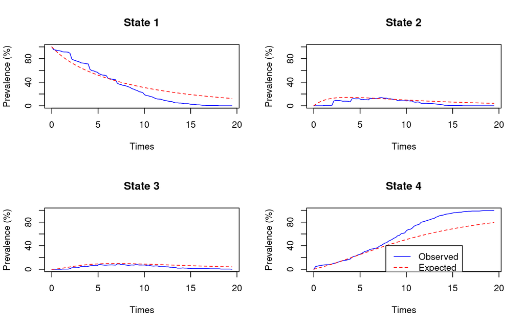

```r
plot.prevalence.msm(cav.msm)
```

## Model with Covariates

```r
cav.msm.1 <- msm(state ~ years
             , subject = PTNUM
             , data = cav
             , qmatrix = Q
             , deathexact = 4
             , covariates = ~ sex
               )

h1 <- hazard.msm(cav.msm.1)

h1$sex %>% prt(caption="Hazard Ratio of sex 1 against 0")
```

Hazard Ratio of sex 1 against 0

|  | HR | L | U |
| --- | --- | --- | --- |
| State 1 - State 2 | 0.5632779 | 0.3333382 | 9.518320e-01 |
| State 1 - State 4 | 1.1289701 | 0.6261976 | 2.035417e+00 |
| State 2 - State 1 | 1.2905854 | 0.4916004 | 3.388139e+00 |
| State 2 - State 3 | 1.0765518 | 0.5193868 | 2.231408e+00 |
| State 2 - State 4 | 0.0003805 | 0.0000000 | 1.999137e+57 |
| State 3 - State 2 | 1.0965531 | 0.1345395 | 8.937364e+00 |
| State 3 - State 4 | 2.4135380 | 1.1762927 | 4.952140e+00 |

```r
sj1 <- sojourn.msm(cav.msm.1, covariate=list(sex=1), ci="norm")
sj0 <- sojourn.msm(cav.msm.1, covariate=list(sex=0), ci="norm")

sj1 %>% prt(caption="Estimated Time for Each State sex=1")
```

Estimated Time for Each State sex=1

|  | estimates | SE | L | U |
| --- | --- | --- | --- | --- |
| State 1 | 8.106755 | 1.4777620 | 5.5868064 | 11.233842 |
| State 2 | 1.553960 | 0.8304127 | 0.0000000 | 2.472661 |
| State 3 | 1.218479 | 0.4488469 | 0.5005559 | 2.259481 |

```r
sj0 %>% prt(caption="Estimated Time for Each State sex=0")
```

Estimated Time for Each State sex=0

|  | estimates | SE | L | U |
| --- | --- | --- | --- | --- |
| State 1 | 5.634780 | 0.3301271 | 5.041437 | 6.321529 |
| State 2 | 1.653057 | 0.1387556 | 1.362682 | 1.934526 |
| State 3 | 2.436049 | 0.3371423 | 1.816691 | 3.192994 |

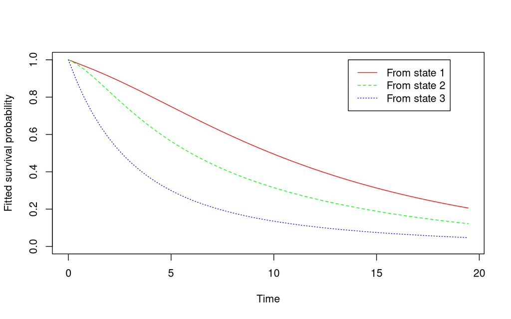

```r
plot(cav.msm)
```

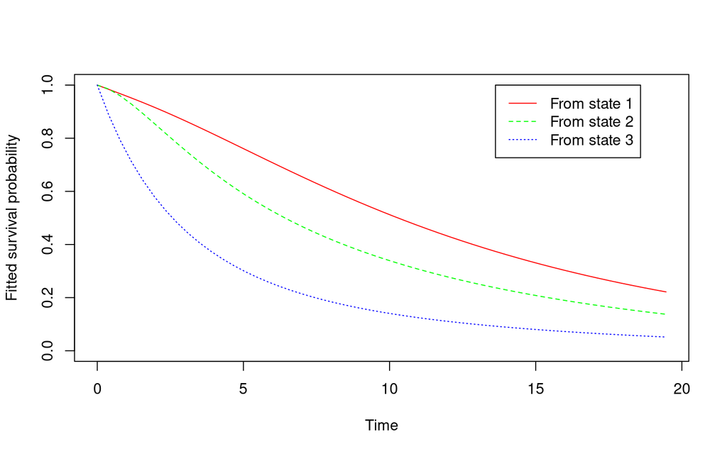

```r
plot(cav.msm.1)
```

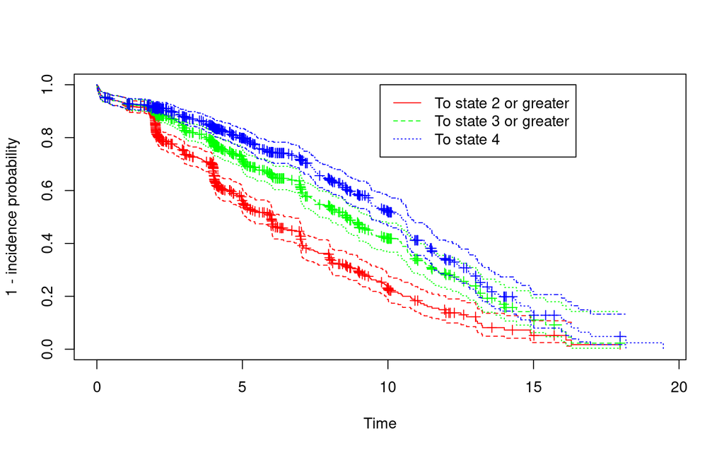

```r
plotprog.msm(state ~ years, subject = PTNUM, data=cav)
```

## Model Comparison

```r
cav.msm <- msm(state ~ years
             , subject = PTNUM
             , data = cav
             , qmatrix = Q
             , deathexact = 4)

cav.msm.1 <- msm(state ~ years
             , subject = PTNUM
             , data = cav
             , qmatrix = Q
             , deathexact = 4
             , covariates = ~ sex
               )

t <- lrtest.msm(cav.msm, cav.msm.1)

t %>% prt(caption="Likelihood Ratio Test: Null model vs sex model"
          , col.names=attr(t, "dimnames")[[2]]
          )
```

Likelihood Ratio Test: Null model vs sex model

|  | -2 log LR | df | p |
| --- | --- | --- | --- |
| cav.msm.1 | 14.02089 | 7 | 0.0508111 |

R version 4.2.0 (2022-04-22) Platform: x86_64-pc-linux-gnu (64-bit) Running under: Ubuntu 20.04.3 LTS

Matrix products: default BLAS: /usr/lib/x86_64-linux-gnu/blas/libblas.so.3.9.0 LAPACK: /usr/lib/x86_64-linux-gnu/lapack/liblapack.so.3.9.0

locale: [1] LC_CTYPE=C.UTF-8 LC_NUMERIC=C LC_TIME=C.UTF-8  
[4] LC_COLLATE=C.UTF-8 LC_MONETARY=C.UTF-8 LC_MESSAGES=C.UTF-8  
[7] LC_PAPER=C.UTF-8 LC_NAME=C LC_ADDRESS=C  
[10] LC_TELEPHONE=C LC_MEASUREMENT=C.UTF-8 LC_IDENTIFICATION=C

attached base packages: [1] stats graphics grDevices utils datasets methods base